# nested-models-seminar

Anna Klezovich

26 07 2019

## Crossed random effects

Датасет про успеваемость учеников в зависимости от пола и социального статуса. При этом про всех известно в каких младших и средних школах они учились.

```r
load('pupils.RData')
head(pupils)
```

```
## # A tibble: 6 x 8
##   PUPIL primary_school_~ secondary_schoo~ achievement sex   ses
##   <dbl>            <dbl>            <dbl>       <dbl> <fct> <fct>
## 1     1                1                2         6.6 fema~ high~
## 2     2                1                1         5.7 male  lowe~
## 3     3                1               17         4.5 male  2
## 4     4                1                3         4.4 male  2
## 5     5                1                4         5.8 male  3
## 6     6                1                4         5   fema~ 4
## # ... with 2 more variables: primary_denominational <fct>,
## #   secondary_denominational <fct>
```

[output not shown]

[output cut: 888 more lines]

[output not shown]

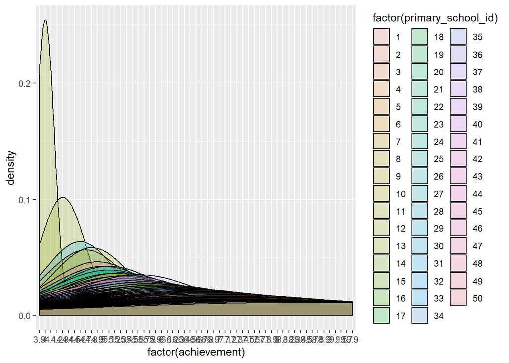

```r
ggplot(pupils, aes(x=factor(achievement), fill=factor(primary_school_id))) +
geom_density(alpha=0.2)
```

[output not shown]

[output cut: 676 more lines]

[output not shown]

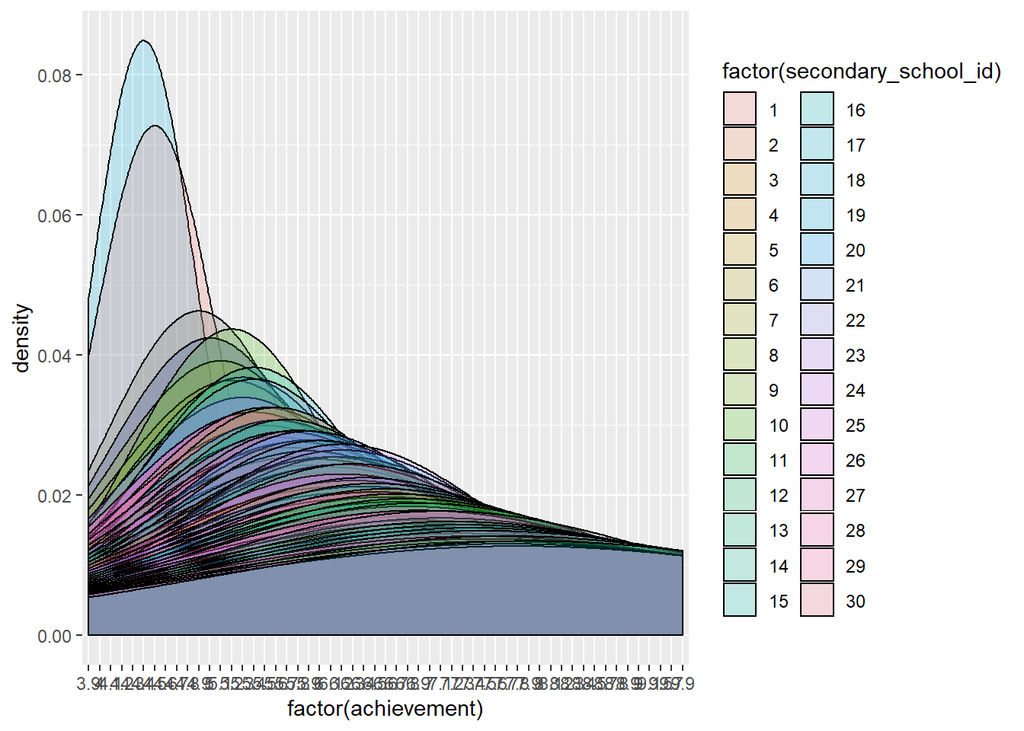

```r
ggplot(pupils, aes(x=factor(achievement), fill=factor(secondary_school_id))) +
geom_density(alpha=0.2)
```

```r
pupils_simple <- lm(achievement ~ sex + ses + primary_school_id,
                      data = pupils)
summary(pupils_simple)
```

```
##
## Call:
## lm(formula = achievement ~ sex + ses + primary_school_id, data = pupils)
##
## Residuals:
##     Min      1Q  Median      3Q     Max
## -2.6076 -0.5766  0.0152  0.5733  3.3369
##
## Coefficients:
##                    Estimate Std. Error t value Pr(>|t|)
## (Intercept)        5.977952   0.123748  48.308  < 2e-16 ***
## sexfemale          0.256066   0.053844   4.756 2.27e-06 ***
## ses2               0.043309   0.140180   0.309  0.75742
## ses3               0.069593   0.131379   0.530  0.59643
## ses4               0.294843   0.124795   2.363  0.01834 *
## ses5               0.349163   0.120653   2.894  0.00389 **
## seshighest         0.539661   0.131967   4.089 4.68e-05 ***
## primary_school_id -0.001117   0.001885  -0.592  0.55378
## ---
## Signif. codes:  0 '***' 0.001 '**' 0.01 '*' 0.05 '.' 0.1 ' ' 1
##
## Residual standard error: 0.8461 on 992 degrees of freedom
## Multiple R-squared:  0.05568,    Adjusted R-squared:  0.04902
## F-statistic: 8.356 on 7 and 992 DF,  p-value: 6.052e-10
```

Смотрите, какой тут маленький r-squared!

То же самое, но с secondary school id

```r
pupils_simple2 <- lm(achievement ~ sex + ses + secondary_school_id,
                      data = pupils)
summary(pupils_simple2)
```

```
##
## Call:
## lm(formula = achievement ~ sex + ses + secondary_school_id, data = pupils)
##
## Residuals:
##     Min      1Q  Median      3Q     Max
## -2.5623 -0.5813 -0.0003  0.5656  3.3663
##
## Coefficients:
##                     Estimate Std. Error t value Pr(>|t|)
## (Intercept)          5.88367    0.12381  47.520  < 2e-16 ***
## sexfemale            0.25857    0.05372   4.813 1.72e-06 ***
## ses2                 0.03872    0.14009   0.276  0.78232
## ses3                 0.06446    0.13120   0.491  0.62333
## ses4                 0.28940    0.12458   2.323  0.02038 *
## ses5                 0.34164    0.12054   2.834  0.00469 **
## seshighest           0.53333    0.13183   4.046 5.62e-05 ***
## secondary_school_id  0.00453    0.00311   1.456  0.14559
## ---
## Signif. codes:  0 '***' 0.001 '**' 0.01 '*' 0.05 '.' 0.1 ' ' 1
##
## Residual standard error: 0.8454 on 992 degrees of freedom
## Multiple R-squared:  0.05736,    Adjusted R-squared:  0.05071
## F-statistic: 8.623 on 7 and 992 DF,  p-value: 2.686e-10
```

```r
pupils_crossed <- lmer(achievement ~ sex + ses
                      + (1|primary_school_id) + (1|secondary_school_id),
                      data = pupils)
summary(pupils_crossed)
```

```
## Linear mixed model fit by REML ['lmerMod']
## Formula:
## achievement ~ sex + ses + (1 | primary_school_id) + (1 | secondary_school_id)
##    Data: pupils
##
## REML criterion at convergence: 2260.9
##
## Scaled residuals:
##     Min      1Q  Median      3Q     Max
## -3.1212 -0.6673 -0.0049  0.6596  3.5676
##
## Random effects:
##  Groups              Name        Variance Std.Dev.
##  primary_school_id   (Intercept) 0.17316  0.4161
##  secondary_school_id (Intercept) 0.06602  0.2570
##  Residual                        0.47312  0.6878
## Number of obs: 1000, groups:
## primary_school_id, 50; secondary_school_id, 30
##
## Fixed effects:
##             Estimate Std. Error t value
## (Intercept)  5.92387    0.12264  48.303
## sexfemale    0.26077    0.04562   5.716
## ses2         0.13188    0.11750   1.122
## ses3         0.09799    0.11010   0.890
## ses4         0.29818    0.10459   2.851
## ses5         0.35376    0.10066   3.514
## seshighest   0.61622    0.11000   5.602
##
## Correlation of Fixed Effects:
##            (Intr) sexfml ses2   ses3   ses4   ses5
## sexfemale  -0.217
## ses2       -0.605  0.014
## ses3       -0.650  0.045  0.671
## ses4       -0.686  0.049  0.706  0.756
## ses5       -0.709  0.052  0.727  0.780  0.820
## seshighest -0.650  0.069  0.664  0.708  0.747  0.774
```

```r
AIC(pupils_crossed, pupils_simple)
```

```
##                df      AIC
## pupils_crossed 10 2280.883
## pupils_simple   9 2513.726
```

Теперь у нас два сета рандомных эффектов для каждого ученика (Но вообще это уже и выше было видно, но вспомним еще раз ranef())

Это вот и называется crossed random effects

```r
glimpse(ranef(pupils_crossed))
```

```
## List of 2
##  $ primary_school_id  :'data.frame': 50 obs. of  1 variable:
##   ..$ (Intercept): num [1:50] -0.327 0.183 0.52 0.474 0.253 ...
##   ..- attr(*, "postVar")= num [1, 1, 1:50] 0.0247 0.0225 0.0244 0.0215 0.0285 ...
##  $ secondary_school_id:'data.frame': 30 obs. of  1 variable:
##   ..$ (Intercept): num [1:30] -0.41069 0.08247 -0.00589 -0.06162 0.08481 ...
##   ..- attr(*, "postVar")= num [1, 1, 1:30] 0.0155 0.014 0.0159 0.0131 0.0142 ...
##  - attr(*, "class")= chr "ranef.mer"
```

## Nested random effects

```r
load('nurses.RData')
head(nurses)
```

```
## # A tibble: 6 x 11
##   hospital  ward wardid nurse   age sex   experience stress wardtype
##      <dbl> <dbl>  <dbl> <dbl> <dbl> <fct>      <dbl>  <dbl> <fct>
## 1        1     1     11     1    36 Male          11      7 general~
## 2        1     1     11     2    45 Male          20      7 general~
## 3        1     1     11     3    32 Male           7      7 general~
## 4        1     1     11     4    57 Fema~         25      6 general~
## 5        1     1     11     5    46 Fema~         22      6 general~
## 6        1     1     11     6    60 Fema~         22      6 general~
## # ... with 2 more variables: hospsize <fct>, treatment <fct>
```

```r
nurses_hier <- lmer(stress ~ age + sex + experience
                           + treatment + wardtype + hospsize
                           + (1|hospital) + (1|hospital:ward),
                           data = nurses)
summary(nurses_hier)
```

```
## Linear mixed model fit by REML ['lmerMod']
## Formula:
## stress ~ age + sex + experience + treatment + wardtype + hospsize +
##     (1 | hospital) + (1 | hospital:ward)
##    Data: nurses
##
## REML criterion at convergence: 1640
##
## Scaled residuals:
##      Min       1Q   Median       3Q      Max
## -2.62082 -0.69562 -0.00134  0.66513  2.75800
##
## Random effects:
##  Groups        Name        Variance Std.Dev.
##  hospital:ward (Intercept) 0.3366   0.5801
##  hospital      (Intercept) 0.1194   0.3455
##  Residual                  0.2174   0.4662
## Number of obs: 1000, groups:  hospital:ward, 100; hospital, 25
##
## Fixed effects:
##                       Estimate Std. Error t value
## (Intercept)           5.379585   0.184686  29.128
## age                   0.022114   0.002200  10.053
## sexFemale            -0.453184   0.034991 -12.952
## experience           -0.061653   0.004475 -13.776
## treatmentTraining    -0.699851   0.119767  -5.843
## wardtypespecial care  0.050807   0.119767   0.424
## hospsizemedium        0.489400   0.201547   2.428
## hospsizelarge         0.901527   0.274824   3.280
##
## Correlation of Fixed Effects:
##             (Intr) age    sexFml exprnc trtmnT wrdtyc hspszm
## age         -0.172
## sexFemale   -0.142 -0.014
## experience  -0.002 -0.817  0.028
## trtmntTrnng -0.326  0.005 -0.004  0.000
## wrdtypspclc -0.324 -0.007 -0.002  0.008  0.000
## hospsizemdm -0.624  0.001 -0.002  0.000  0.000  0.000
## hospsizelrg -0.458 -0.001  0.004  0.002  0.000  0.000  0.419
```

A теперь сравним, что будет, если мы для модели, где рандомные эффекты логически устроены как nested, зафитим модель с crossed радномными эффектами.

```r
nurses_crossed <- lmer(stress ~ age  + sex + experience
                           + treatment + wardtype + hospsize
                           + (1|hospital) + (1|wardid), data = nurses)
summary(nurses_crossed)
```

```
## Linear mixed model fit by REML ['lmerMod']
## Formula:
## stress ~ age + sex + experience + treatment + wardtype + hospsize +
##     (1 | hospital) + (1 | wardid)
##    Data: nurses
##
## REML criterion at convergence: 1640
##
## Scaled residuals:
##      Min       1Q   Median       3Q      Max
## -2.62082 -0.69562 -0.00134  0.66513  2.75800
##
## Random effects:
##  Groups   Name        Variance Std.Dev.
##  wardid   (Intercept) 0.3366   0.5801
##  hospital (Intercept) 0.1194   0.3455
##  Residual             0.2174   0.4662
## Number of obs: 1000, groups:  wardid, 100; hospital, 25
##
## Fixed effects:
##                       Estimate Std. Error t value
## (Intercept)           5.379585   0.184686  29.128
## age                   0.022114   0.002200  10.053
## sexFemale            -0.453184   0.034991 -12.952
## experience           -0.061653   0.004475 -13.776
## treatmentTraining    -0.699851   0.119767  -5.843
## wardtypespecial care  0.050807   0.119767   0.424
## hospsizemedium        0.489400   0.201547   2.428
## hospsizelarge         0.901527   0.274824   3.280
##
## Correlation of Fixed Effects:
##             (Intr) age    sexFml exprnc trtmnT wrdtyc hspszm
## age         -0.172
## sexFemale   -0.142 -0.014
## experience  -0.002 -0.817  0.028
## trtmntTrnng -0.326  0.005 -0.004  0.000
## wrdtypspclc -0.324 -0.007 -0.002  0.008  0.000
## hospsizemdm -0.624  0.001 -0.002  0.000  0.000  0.000
## hospsizelrg -0.458 -0.001  0.004  0.002  0.000  0.000  0.419
```

Упс, ничего не поменялось

**Если мы для nested данных зафитим crossed модель, ничего не произойдет. Но наоборот это не работает!!!**

"The blurring of mixed-effects models with the concept of multiple, hierarchical levels of variation results in an unwarranted emphasis on ‘levels’ when defining a model and leads to considerable confusion. It is perfectly legitimate to define models having random effects associated with non-nested factors. The reasons for the emphasis on defining random effects with respect to nested factors only are that such cases do occur frequently in practice, and that some of the computational methods for estimating the parameters in the models can only be easily applied to nested factors.

This is not the case for the methods used in the lme4 package. Indeed there is nothing special done for models with random effects for nested factors. When random effects are associated with multiple factors, exactly the same computational methods are used whether the factors form a nested sequence or are partially crossed or are completely crossed."

## Schools dataset

Тут на слайдах есть объяснение

## Мидии и еще немного про модели с вложенными эффектами

Из курса СПбГУ

Как подобрать лучшую формулу для данных с nested random effects

```r
astr2 <- read.csv('aster_mussel_full.csv', header = TRUE)
head(astr2)
```

```
##   Year Experiment Box    L Sp   Outcome
## 1 2015       Exp2 2_1 31.2 Ed not_eaten
## 2 2015       Exp2 2_1 36.5 Tr not_eaten
## 3 2015       Exp2 2_1 37.9 Tr not_eaten
## 4 2015       Exp2 2_1 26.2 Tr not_eaten
## 5 2015       Exp2 2_1 33.3 Tr not_eaten
## 6 2015       Exp2 2_1 20.1 Tr not_eaten
```

```r
str(astr2)
```

```
## 'data.frame':    1108 obs. of  6 variables:
##  $ Year      : int  2015 2015 2015 2015 2015 2015 2015 2015 2015 2015 ...
##  $ Experiment: Factor w/ 4 levels "Exp2","Exp3",..: 1 1 1 1 1 1 1 1 1 1 ...
##  $ Box       : Factor w/ 41 levels "2_1","2_2","2_3",..: 1 1 1 1 1 1 1 1 1 1 ...
##  $ L         : num  31.2 36.5 37.9 26.2 33.3 20.1 24.3 27.6 29.4 25 ...
##  $ Sp        : Factor w/ 2 levels "Ed","Tr": 1 2 2 2 2 2 1 1 1 1 ...
##  $ Outcome   : Factor w/ 2 levels "eaten","not_eaten": 2 2 2 2 2 2 2 2 2 2 ...
```

Поправим переменные

```r
astr2$Year <- factor(astr2$Year)
astr2$Out <- ifelse(test = astr2$Outcome == 'eaten', yes = 1,  no = 0)
```

Вчера у нас на семинаре не захотелась считаться anova для нескольких моделей и мы делали что-то такое: speed_dating[!is.na(speed_dating$intelligent_sc),]

Но это можно делать более аккуратно:

```r
colSums(is.na(astr2))
```

```
##       Year Experiment        Box          L         Sp    Outcome
##          0          0          0          0          0          0
##        Out
##          0
```

Смотрим нет ли большого дисбаланса в выборке

```r
table(astr2$Box)
```

```
##
##  2_1  2_2  2_3  2_4  2_5  2_6  2_7  2_8  2_9  3_1  3_2  3_3  3_4  3_5  3_6
##   24   21   24   23   25   22   22   24   23   24   25   23   24   22   23
##  3_7  3_8  3_9  4_1 4_10 4_11 4_12  4_2  4_3  4_4  4_5  4_6  4_7  4_8  4_9
##   24   24   24   30   30   31   30   30   30   31   29   30   30   29   29
##  5_1 5_10 5_12  5_2  5_3  5_4  5_5  5_6  5_7  5_8  5_9
##   29   36   29   30   25   36   30   29   26   28   30
```

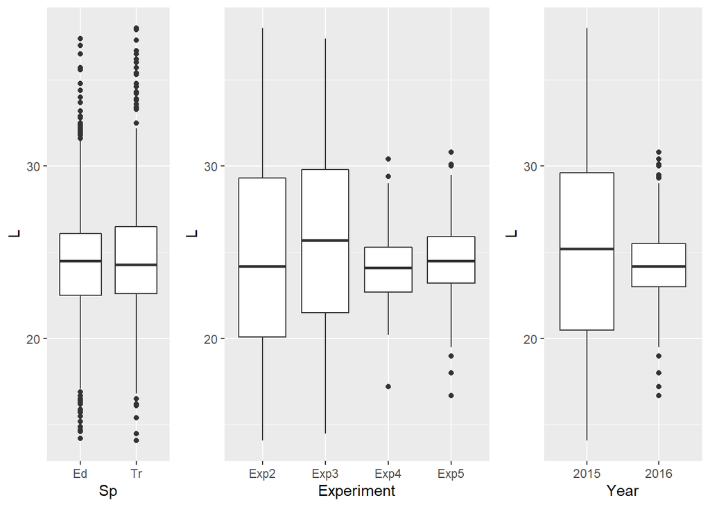

```r
library(cowplot)
Pl_Sp   <- ggplot(astr2, aes(x = Sp, y = L)) + geom_boxplot()
Pl_exp  <- ggplot(astr2, aes(x = Experiment, y = L)) + geom_boxplot()
Pl_year <- ggplot(astr2, aes(x = Year, y = L)) + geom_boxplot()
plot_grid(Pl_Sp, Pl_exp, Pl_year, ncol = 3, rel_widths = c(0.25, 0.45, 0.3))
```

Нужно включить в модель взаимодействие между годом и длиной L, потому что видно что в 2016 что-то не так пошло. Всё остальное нормально более-менее

```r
model1_ri <- glmer(Out ~ L * Sp * Year + (1|Experiment/Box),
                   data = astr2, family = binomial(link = 'logit'))
summary(model1_ri)
```

```
## Generalized linear mixed model fit by maximum likelihood (Laplace
##   Approximation) [glmerMod]
##  Family: binomial  ( logit )
## Formula: Out ~ L * Sp * Year + (1 | Experiment/Box)
##    Data: astr2
##
##      AIC      BIC   logLik deviance df.resid
##   1081.7   1131.8   -530.8   1061.7     1098
##
## Scaled residuals:
##     Min      1Q  Median      3Q     Max
## -1.4839 -0.5425 -0.3876 -0.2746  4.4296
##
## Random effects:
##  Groups         Name        Variance Std.Dev.
##  Box:Experiment (Intercept) 0.07624  0.2761
##  Experiment     (Intercept) 0.05409  0.2326
## Number of obs: 1108, groups:  Box:Experiment, 41; Experiment, 4
##
## Fixed effects:
##                 Estimate Std. Error z value Pr(>|z|)
## (Intercept)      0.75048    0.87552   0.857  0.39134
## L               -0.10006    0.03636  -2.752  0.00593 **
## SpTr             1.81520    1.15388   1.573  0.11569
## Year2016         1.26560    1.96990   0.642  0.52057
## L:SpTr          -0.03178    0.04754  -0.669  0.50378
## L:Year2016      -0.06345    0.08161  -0.777  0.43690
## SpTr:Year2016   -3.65554    2.74839  -1.330  0.18350
## L:SpTr:Year2016  0.15192    0.11378   1.335  0.18179
## ---
## Signif. codes:  0 '***' 0.001 '**' 0.01 '*' 0.05 '.' 0.1 ' ' 1
##
## Correlation of Fixed Effects:
##             (Intr) L      SpTr   Yr2016 L:SpTr L:Y201 ST:Y20
## L           -0.957
## SpTr        -0.724  0.720
## Year2016    -0.443  0.424  0.321
## L:SpTr       0.727 -0.757 -0.977 -0.322
## L:Year2016   0.425 -0.444 -0.320 -0.985  0.337
## SpTr:Yr2016  0.305 -0.306 -0.419 -0.700  0.410  0.700
## L:SpT:Y2016 -0.305  0.319  0.407  0.700 -0.418 -0.711 -0.993
## convergence code: 0
## Model failed to converge with max|grad| = 0.00386958 (tol = 0.001, component 1)
```

```r
?convergence
```

```
## starting httpd help server ... done
```

Можно стандартизировать предиктор

```r
astr2$L_scaled <- as.numeric(scale(astr2$L))

model1_ri <- glmer(Out ~ L_scaled * Sp * Year + (1|Experiment/Box),
                   data = astr2, family = binomial(link = 'logit'))
```

Ну всё, у нас всё прикольно, давайте усложним модель

```r
model1_rsi <- glmer(Out ~ L_scaled * Sp * Year + (1 + L_scaled |Experiment/Box),
                      data = astr2, family = binomial(link = 'logit'))
```

Можно попробовать ослабить правила и разрешить модели сходится дольше/больше эпох

```r
model1_rsi <- glmer(Out ~ L_scaled * Sp * Year + (1 + L_scaled |Experiment/Box) ,
            data = astr2, family = binomial(link = 'logit'),
            control = glmerControl(optimizer = 'bobyqa', optCtrl = list(maxfun = 2e5)))
```

```
## boundary (singular) fit: see ?isSingular
```

```r
AIC(model1_ri, model1_rsi)
```

```
##            df      AIC
## model1_ri  10 1081.682
## model1_rsi 14 1087.618
```

Выбрали модель

Stepwise model selection

Функция drop1(), чтобы выбирать между моделями, какие предикторы включать, а какие нет

```r
drop1(model1_ri)
```

```
## Single term deletions
##
## Model:
## Out ~ L_scaled * Sp * Year + (1 | Experiment/Box)
##                  Df    AIC
## <none>              1081.7
## L_scaled:Sp:Year  1 1081.5
```

```r
model2 <- update(model1_ri, .~.-L_scaled:Sp:Year)

drop1(model2)
```

```
## Single term deletions
##
## Model:
## Out ~ L_scaled + Sp + Year + (1 | Experiment/Box) + L_scaled:Sp +
##     L_scaled:Year + Sp:Year
##               Df    AIC
## <none>           1081.5
## L_scaled:Sp    1 1079.5
## L_scaled:Year  1 1079.5
## Sp:Year        1 1079.5
```

```r
model3 <- update(model2, . ~ . - L_scaled:Year)

drop1(model3)
```

```
## Single term deletions
##
## Model:
## Out ~ L_scaled + Sp + Year + (1 | Experiment/Box) + L_scaled:Sp +
##     Sp:Year
##             Df    AIC
## <none>         1079.5
## L_scaled:Sp  1 1077.5
## Sp:Year      1 1077.5
```

```r
model4 <- update(model3, . ~ . - L_scaled:Sp)

drop1(model4)
```

```
## Single term deletions
##
## Model:
## Out ~ L_scaled + Sp + Year + (1 | Experiment/Box) + Sp:Year
##          Df    AIC
## <none>      1077.5
## L_scaled  1 1107.5
## Sp:Year   1 1075.5
```

```r
model5 <- update(model4, . ~ . - Sp:Year)

drop1(model5)
```

```
## Single term deletions
##
## Model:
## Out ~ L_scaled + Sp + Year + (1 | Experiment/Box)
##          Df    AIC
## <none>      1075.5
## L_scaled  1 1105.8
## Sp        1 1120.7
## Year      1 1074.1
```

```r
model6 <- update(model5, . ~ . - Year)

# Финальная модель
drop1(model6)
```

```
## Single term deletions
##
## Model:
## Out ~ L_scaled + Sp + (1 | Experiment/Box)
##          Df    AIC
## <none>      1074.1
## L_scaled  1 1104.4
## Sp        1 1119.5
```

```r
AIC(model1_ri, model6)
```

```
##           df      AIC
## model1_ri 10 1081.682
## model6     5 1074.137
```

```r
summary(model6)$call
```

```
## glmer(formula = Out ~ L_scaled + Sp + (1 | Experiment/Box), data = astr2,
##     family = binomial(link = "logit"))
```